# *padma* package: Quick-start guide

Andrea Rau

INRAE

andrea.rau@inrae.fr

2020-01-09

#### Package

padma 0.1.1

[figure not shown]

*padma* is a package that uses multiple factor analysis to calculate individualized pathway-centric scores of deviation with respect to the sampled population based on multi-omic assays (e.g., RNA-seq, copy number alterations, methylation, etc). In particular, *padma* characterizes individuals with aberrant multi-omic profiles for a given pathway of interest and quantifies this deviation with respect to the sampled population using a multi-omic consensus representation. Graphical and numerical outputs are provided to identify highly aberrant individuals for a particular pathway of interest, as well as the gene and omics drivers of aberrant multi-omic profiles.

The method implemented in this package is described in greater detail in the following pre-print:

> Rau, A., Manansala, R., Flister, M. J., Rui, H., Jaffrézic, F., Laloë, D.*, and Auer, P. L.* (2019) Individualized multi-omic pathway deviation scores using multiple factor analysis bioRxiv, https://doi.org/10.1101/827022. *These authors contributed equally to this work.

Below, we provide a quick-start guide using a subset of the TCGA LUAD multi-omic data (included with the *padma* package) to illustrate the functionalities and output of the method.

# 1 Quick start (tl;dr)

As with any R package, after installation the *padma* package is loaded as follows:

```r
library(padma)
```

Multi-omic data must be formatted as a named list of `data.frames`, including at least `clinical` with clinical phenotype and `rnaseq` containing RNA-seq data (see below for more description of data formatting), with individuals sorted in the same order across datasets. A small example dataset is provided in `LUAD_subset` for multi-omic data (clinical, RNA-seq, CNA, methylation, miRNA-seq) on 13 genes from the D4-GDI signaling pathway in individuals with lung adenocarcinoma from TCGA.

A standard *padma* analysis for the D4-GDI signalling pathway takes as input these formatted data and the name of the desired pathway. Built-in pathway names and gene lists from the MSigDB curated pathway set are provided in the `msigdb` data provided with *padma*.

```r
D4GDI <- msigdb[grep("D4GDI", msigdb$geneset),
                "geneset"]
run_padma <- padma(LUAD_subset,
                   pathway_name = D4GDI)
```

A variety of plots can then be obtained, including a factor map or partial factor map of individuals, and a plot of the percentage contribution to each component by each considered omics.

```r
plot_factor_map(run_padma)
plot_partial_factor_map(run_padma,
                        id = "TCGA-78-7536")
plot_omics_contrib(run_padma)
```

Numerical output included in the `run_padma` S3 object of class `padma` include for example the individualized (overall and per-gene) pathway deviation scores, MFA eigenvalues, full and partial MFA coordinates. See the following section for a more detailed description of these outputs.

# 2 Description of *padma*

A portion of the following text is taken from [Rau et al. (2019)](https://doi.org/10.1101/827022).

## 2.1 Overview of Multiple Factor Analysis

Multiple factor analysis (MFA) represents an extension of principal component analysis for the case where multiple quantitative data tables are to be simultaneously analyzed. In particular, the MFA approach weights each table individually to ensure that tables with more features or those on a different scale do not dominate the analysis; all features within a given table are given the same weight. These weights are chosen such that the first eigenvalue of a PCA performed on each weighted table is equal to 1, ensuring that all tables play an equal role in the global multi-table analysis. According to the desired focus of the analysis, data can be structured either with molecular assays (e.g., RNA-seq, methylation, miRNA-seq, copy number alterations) as tables (and genes as features within omics), or with genes as tables (and molecular assays as features within genes). The MFA weights balance the contributions of each omic or of each gene, respectively. In *padma*, we focus on the latter strategy in order to allow different omics to contribute to a varying degree depending on the chosen pathway.

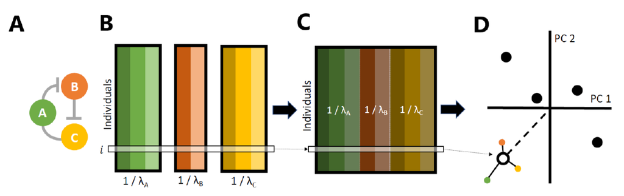

Figure 1 from [Rau et al. (2019)](https://doi.org/10.1101/827022), illustrating the *padma* approach.

More precisely, consider a pathway or gene set composed of $p$ genes (Figure 1A), each of which is measured using up to $k$ molecular assays (e.g., RNA-seq, methylation, miRNA-seq, copy number alterations), contained in the set of gene-specific matrices $X_1,\ldots, X_p$ that have the same $n$ matched individuals (rows) and $j_1,\ldots, j_p$ potentially unmatched variables (columns) in each, where $j_g \in \lbrace 1, \ldots, k\rbrace$ for each gene $g = 1,\ldots, p$. Because only the observations and not the variables are matched across data tables, genes may be represented by potentially different subset of omics data (e.g., only expression data for one gene, and expression and methylation data for another).

In the first step, these data tables are generally standardized (i.e., centered and scaled). Next, an individual PCA is performed using singular value decomposition for each gene table $X_g$, and its largest singular value $\lambda_g^1$ is calculated (Figure 1B). Then, all features in each gene table $X_g$ are weighted by $1/\lambda_g^1$, and a global PCA is performed using a singular value decomposition on the concatenated set of weighted standardized tables, $X^\ast = \left[ \frac{X_1}{\lambda_1^1}, \ldots, \frac{X_p}{\lambda_p^1}\right]$ (Figure 1C). This yields a matrix of components (i.e., latent variables) in the observation and variable space.

The MFA thus provides a consensus across-gene representation of the individuals for a given pathway, and the global PCA performed on the weighted gene tables decomposes the consensus variance into orthogonal variables (i.e., principal components) that are ordered by the proportion of variance explained by each. The coordinates of each individual on these components, also referred to as factor scores, can be used to produce factor maps to represent individuals in this consensus space such that smaller distances reflect greater similarities among individuals. In addition, partial factor scores, which represent the position of individuals in the consensus for a given gene, can also be represented in the consensus factor map; the average of partial factor scores across all dimensions and genes for a given individual corresponds to the factor score (Figure 1D).

## 2.2 Calculation of individualized pathway deviation scores

In the consensus space obtained from the MFA, the origin represents the ``average" pathway behavior across genes, omics, and individuals; individuals that are projected to increasingly distant points in the factor map represent those with increasingly aberrant values, with respect to this average, for one or more of the omics measures for one or more genes in the pathway. To quantify these aberrant individuals, we propose an individualized pathway deviation score $d_i$ based on the multidimensional Euclidean distance of the MFA component loadings for each individual to the origin:
$$\begin{equation*}
d_i^2 = \sum_{\ell = 1}^L f_{i,\ell}^2,
\end{equation*}$$
where $f_{i,\ell}$ corresponds to the MFA factor score of individual $i$ in component $\ell$, and $L$ corresponds to the rank of $X^\ast$. Note that this corresponds to the weighted Euclidean distance of the scaled multi-omic data (for the genes in a given pathway) of each individual to the origin. These individualized pathway deviation scores are thus nonnegative, where smaller values represent individuals for whom the average multi-omic pathway variation is close to the average, while larger scores represent individuals with increasingly aberrant multi-omic pathway variation with respect to the average. An individual with a large pathway deviation score is thus characterized by one or more genes, with one or more omic measures, that explain a large proportion of the global correlated information across the full pathway.

## 2.3 Calculation of individualized per-gene deviation scores

In order to quantify the role played by each gene for each individual, we decompose the individualized pathway deviation scores into gene-level contributions. Recall that the average of partial factor scores across all MFA dimensions corresponds to each individual’s factor score. We define the gene-level deviation for a given individual as follows:
$$\begin{equation*}
d_{i,g} = \frac{\sum_{\ell = 1}^L f_{i,\ell}\left(f_{i,\ell,g}-f_i\right)}{\sum_{\ell = 1}^L f_{i,\ell}^2},
\end{equation*}$$
where as before $f_{i,\ell}$ corresponds to the MFA factor score of individual $i$ in component $\ell$, $L$ corresponds to the rank of $X^\ast$, and $f_{i,\ell,g}$ corresponds to the MFA partial factor score of individual $i$ in gene $g$ in component $\ell$. Note that by construction, the contributions of all pathway genes to the overall deviation score sum to 0. In particular, per-gene contributions can take on both negative and positive values according to the extent to which the gene influences the deviation of the overall pathway score from the origin (i.e., the global center of gravity across individuals); large positive values correspond to tables with a large influence on the overall deviation of an individual, while large negative values correspond to genes that tend to be most similar to the global average.

# 3 Description of built-in datasets

## 3.1 `LUAD_subset`: D4-GDI signaling pathway in the TCGA-LUAD multi-omic data

In this vignette, we focus on the example of multi-omic (RNA-seq, methylation, copy number alterations, and miRNA-seq) data for the D4-GDI signaling pathway from individuals with lung adenocarcinoma (LUAD) from The Cancer Genome Atlas (TCGA) database. The multi-omic TCGA data were downloaded and processed as [previously described](https://doi.org/10.5281/zenodo.3524080), including batch correction for the plate effect. The total number of individuals considered here is $n=144$. See [Rau et al. (2019)](https://doi.org/10.1101/827022) for additional details about data processing and mapping of miRNAs to genes.

The D4-GDP dissociation inhibitor (GDI) signaling pathway is made up of 13 genes; it was chosen for follow-up here as it was identified as having individualized pathway deviation scores that are significantly positively correlated with smaller progression-free intervals. RNA-seq, methylation, and CNA measures are available for all 13 genes, with the exception of CYCS and PARP1, for which no methylation probes were measured the promoter region. In addition, miRNA-seq data were included for one predicted target pair: hsa-mir-421 $\rightarrow$ CASP3.

The available multi-omic data for the D4-GDI signaling pathway in TCGA LUAD patients is included within the *padma* package as the `LUAD_subset` object, which is a named list of `data.frames` each containing the relevant data (clinical parameters, RNA-seq, methylation, miRNA-seq, CNA) for the $p=13$ genes of the D4-GDI pathway in the $n=144$ individuals.

```r
names(LUAD_subset)
```

```
#> [1] "clinical" "rnaseq"   "methyl"   "mirna"    "cna"
```

```r
lapply(LUAD_subset, class)
```

```
#> $clinical
#> [1] "data.frame"
#>
#> $rnaseq
#> [1] "data.frame"
#>
#> $methyl
#> [1] "data.frame"
#>
#> $mirna
#> [1] "data.frame"
#>
#> $cna
#> [1] "data.frame"
```

```r
lapply(LUAD_subset, dim)
```

```
#> $clinical
#> [1] 144  55
#>
#> $rnaseq
#> [1]  13 145
#>
#> $methyl
#> [1]  13 145
#>
#> $mirna
#> [1]   1 146
#>
#> $cna
#> [1]  13 145
```

There are some important data formatting issues that are worth mentioning here:

- The individual datasets have been sorted so that individuals appear in the same order. The clinical data (`LUAD_subset$clinical`) have individuals as rows and clinical variables as columns; all other datasets with the exception of `LUAD_subset$mirna` have genes as rows and individuals as columns (where, in addition, the first column contains a column entitled `gene` providing the corresponding gene symbol for each row). The remaining column names correspond to the patient barcodes that are also provided in the `bcr_patient_barcode` column of `LUAD_subset$clinical`. For `LUAD_subset$mirna`, the first two columns represent the miRNA ID (`miRNA_lc`) and corresponding targeted gene symbol (`gene`).
- All omics data have already been appropriately pre-processed before subsetting to this pathway (e.g., RNA-seq data have been normalized and log-transformed).
- Although *padma* does require that all datasets have the same number of individuals, and that all datasets are sorted so that individuals are in the same order, each dataset does not need to represent every considered gene. Note that in these data, a single gene (CASP3) is predicted to be targeted by a miRNA (hsa-mir-421).
- The `clinical` and `rnaseq` datasets are both currently required. Additional omics datasets (`cna`, `mirna`, `methyl`) can optionally be included if desired; beyond this, *padma* is not yet equipped to handle more general types of data. In addition, *padma* expects a `bcr_patient_barcode` column in the `clinical` data.
- Finally, these data have been subsetted to include only values relevant to the D4-GDI signaling pathway solely in the interest of space. In practice, users do not need to subset their data prior to input in *padma* or match miRNAs to genes, as both of these steps are performed automatically for a user-provided pathway name or set of genes.

## 3.2 `msigdb`: the MSigDB canonical pathway gene sets

In our work, we considered the pathways included in the MSigDB canonical pathways curated gene set catalog, which includes genes whose products are involved in metabolic and signaling pathways reported in curated public databases. We specifically used the 1322 “C2 curated gene sets” catalog from 601MSigDB v5.2 available at http://bioinf.wehi.edu.au/software/MSigDB/as described in the [*limma*](https://bioconductor.org/packages/release/bioc/html/limma.html) Bioconductor package. For convenience, the gene sets corresponding to each pathway have been included in the `msigdb` data frame:

```r
head(msigdb)
```

```
#>                         geneset
#> 1   c2_cp_BIOCARTA_41BB_PATHWAY
#> 2   c2_cp_BIOCARTA_ACE2_PATHWAY
#> 3    c2_cp_BIOCARTA_ACH_PATHWAY
#> 4 c2_cp_BIOCARTA_ACTINY_PATHWAY
#> 5  c2_cp_BIOCARTA_AGPCR_PATHWAY
#> 6    c2_cp_BIOCARTA_AGR_PATHWAY
#>                                                                                                                                                                                                                            symbol
#> 1                                                                                                              JUN, MAP3K5, MAPK8, CHUK, MAPK14, MAP3K1, RELA, TNFRSF9, IKBKB, MAP4K5, IFNG, TRAF2, ATF2, IL4, NFKB1, NFKBIA, IL2
#> 2                                                                                                                                         ACE2, COL4A1, COL4A2, REN, COL4A3, COL4A4, CMA1, AGT, AGTR1, ACE, AGTR2, COL4A6, COL4A5
#> 3                                                                                                                      SRC, PTK2, TERT, CHRNG, FOXO3, RAPSN, AKT1, PIK3CA, MUSK, FASLG, CHRNB1, YWHAH, BAD, PTK2B, PIK3CG, PIK3R1
#> 4                                                                                         ABI2, WASF2, WASL, ACTA1, PIR, WASF1, ARPC4, PSMA7, ARPC5, ARPC1A, ACTR2, ACTR3, ARPC1B, ARPC3, NCKAP1, WASF3, ARPC2, RAC1, NTRK1, NCK1
#> 5                                                                                                                                PRKCB, PRKCA, PRKAR2B, PRKACB, PRKACG, GNAS, ARRB1, GNGT1, GNB1, PRKAR1A, PRKAR2A, PRKAR1B, GRK4
#> 6 JUN, MAPK8, PAK3, ACTA1, EGFR, NRG1, RAPSN, DAG1, CHRM1, PAK2, LAMA3, LAMA2, PAK4, UTRN, PXN, NRG3, PAK7, DMD, CTTN, SRC, PTK2, ITGA1, CHRNA1, PAK1, SP1, GIT2, DVL1, NRG2, MUSK, ITGB1, MAPK3, LAMA4, RAC1, PAK6, CDC42, MAPK1
```

In practice, to use *padma* a user can either directly provide a vector of gene symbols, or the geneset name as defined in this data frame (e.g., `c2_cp_BIOCARTA_41BB_PATHWAY`).

## 3.3 `mirtarbase`: predicted gene targets of miRNAs

*padma* integrates multi-omic data by mapping omics measures to genes in a given pathway. Although this assignment of values to genes is relatively straightforward for RNA-seq, CNA, and methylation data, a definitive mapping of miRNA-to-gene relationships does not exist, as miRNAs can each potentially target multiple genes. Many methods and databases based on text-mining or bioinformatics-driven approaches exist to predict miRNA-target pairs. Here, we make use of the curated miR-target interaction (MTI) predictions in [miRTarBase](http://mirtarbase.mbc.nctu.edu.tw/php/index.php) (version 7.0), using only exact matches for miRNA IDs and target gene symbols and predictions with the “Functional MTI” support type. As a reference, we have included these predictions in the built-in `mirtarbase` data frame:

```r
head(mirtarbase)
```

```
#>             miRNA Target Gene
#> 1  hsa-miR-20a-5p       HIF1A
#> 2  hsa-miR-20a-5p       HIF1A
#> 3 hsa-miR-146a-5p       CXCR4
#> 4 hsa-miR-146a-5p       CXCR4
#> 5  hsa-miR-122-5p      CYP7A1
#> 6  hsa-miR-222-3p      STAT5A
```

In practice, unless an alternative data frame is provided for the `mirna_targets` argument of *padma*, the `mirtarbase` data frame is used to match miRNA IDs to gene symbols.

# 4 Running *padma*

To run *padma* for the D4-GDI pathway, the following command is used:

```r
D4GDI <- msigdb[grep("D4GDI", msigdb$geneset), "geneset"]
run_padma <- padma(LUAD_subset,
                   pathway_name = D4GDI)
```

```
#> The following are removed from methyl in base due to small variance or all NAs:
#> [1] "CYCS"  "PARP1"
```

Note that we have used the `misgdb` built-in database to find the full name of the D4-GDI pathway, `"c2_cp_BIOCARTA_D4GDI_PATHWAY"`. Alternatively, a vector of gene symbols for the pathway of interest could be provided to the `pathway_name` argument:

```r
D4GDI_genes <- unlist(strsplit(msigdb[grep("D4GDI", msigdb$geneset), "symbol"],
                        ", "))
D4GDI_genes
run_padma_again <- padma(LUAD_subset,
                   pathway_name = D4GDI_genes)
```

As noted above, it is required to provide either a recognized pathway name (see `msigdb$geneset`) or a vector of gene symbols. In most cases, users would provide the full multi-omics data in the `omics_data` argument of `padma`, rather than a pre-subsetted dataset as is the case for the built-in `LUAD_subset` data.

In the following, we detail the various numerical and graphical outputs that can be accessed after running `padma`; note that the results are an S3 object of class `"padma"`, somewhat analagous to a named list.

## 4.1 Numerical outputs

The numerical outputs of `padma` include the following (which can all be accessed using `$`, e.g. `run_padma$Pathway_Name`):

There are two primary numerical outputs from `padma`:  
- `pathway_deregulation`: a `data.frame` providing the individualized pathway deviation scores for each individual. The `group` column indicates whether an individual was included as part of the reference population (`"Base"`) or as a supplementary individual projected onto the reference (`"Supp"`), as indicated by the user in the `base_ids` and `supp_ids` arguments of `padma`. - `pathway_gene_deregulation`: matrix of dimension $n$ (nuumber of individuals) x $p$ (number of genes in the pathway) containing the individualized per-gene deviation scores

There are also several outputs related to the MFA itself, and obtained via the [*FactorMineR*](http://factominer.free.fr/) R package implementation of the MFA:

- `eig`: matrix of dimension $c$ (number of MFA components) x 3 providing the respective eigenvalues, percentage of variance explained, and cumulative percentage of variance explained by each MFA component
- `partial_coordinates_MFA`: matrix of the partial MFA components (only included when `full_results = TRUE`)
- `ind_contrib_MFA`: matrix of the percentage variance explained by each individual for each MFA component (when `full_results = TRUE`) or cumulatively for the first 10 and across all components (when `full_results = FALSE`)
- `gene_contrib_MFA`: matrix of the percentage variance explained by each individual for each MFA component (when `full_results = TRUE`) or cumulatively for the first 10 and across all components (when `full_results = FALSE`)
- `gene_Lg_MFA`: matrix of the pairwise Lg coefficient between genes (only included when `full_results = TRUE`)
- `omics_contrib_MFA` : matrix of the percentage variance explained by each omics for each MFA component (when `full_results = TRUE`) or cumulatively for the first 10 and across all components (when `full_results = FALSE`)
- `total_MFA`: object of class `"MFA"` representing the full *FactoMineR* output for the MFA (only included when `full_results = TRUE`)

Finally, there are additionally a couple of general informative outputs:

- `Pathway_Name`: user-provided name of pathway analyzed by `padma`. If a vector of gene symbols was provided rather than a built-in name, `"custom"` is returned.
- `ngenes`: number of genes with at least RNA-seq data available in the pathway
- `imputed_genes`: gene symbols of genes for which values were automatically imputed by `padma`
- `removed_genes`: gene symbols of genes which were automatically removed by `padma` due to small variance (< 10e-5) or all missing values across samples
- `gene_tables`: formatted multi-omic pathway-specific data (after imputation and standardization) fed into the MFA

## 4.2 Graphical outputs

*padma* includes three primary plotting functions:

- `plot_factor_map`: plot the MFA components for each individual for a selected pair of components. This would typically be done for the first few components, and serves as a visualization of the structuring of indviduals for the pathway; for example, below the factor map suggests that individual TCGA-78-7536 is likely to have a larger overall pathway deviation score given that it is positioned quite far from the origin (for these two axes).

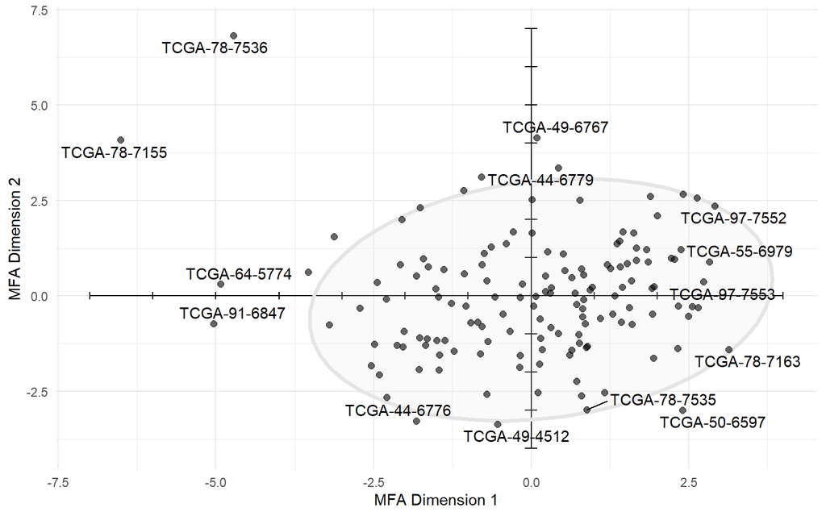

```r
plot_factor_map(run_padma, dim_x = 1, dim_y = 2)
```

- `plot_partial_factor_map`: plot the MFA partial components for one specific individual for a pair of components. This function would be used to zero in on one or several indivduals (for example, TCGA-78-7536) to visualize which genes appear to be pulling the overall score away from the origin. Here we note the seeming large influence of CASP10 and CASP3. Note that the individual’s overall pathway score, which is represented as the large black point, is the same as that from the previous plot.

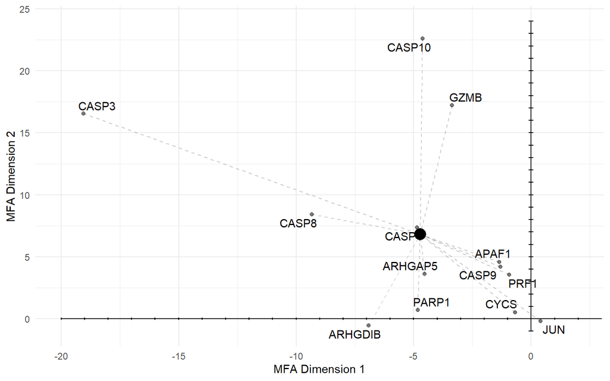

```r
plot_partial_factor_map(run_padma,
                        id = "TCGA-78-7536",
                        dim_x = 1,
                        dim_y = 2)
```

- `plot_omics_contrib`: visualize the contribution of each omics to the variation of a subset of MFA components, and summarize this contribution as a weighted overall average. In this plot, transparency of the bars reflects the percentage variance explained for each component.

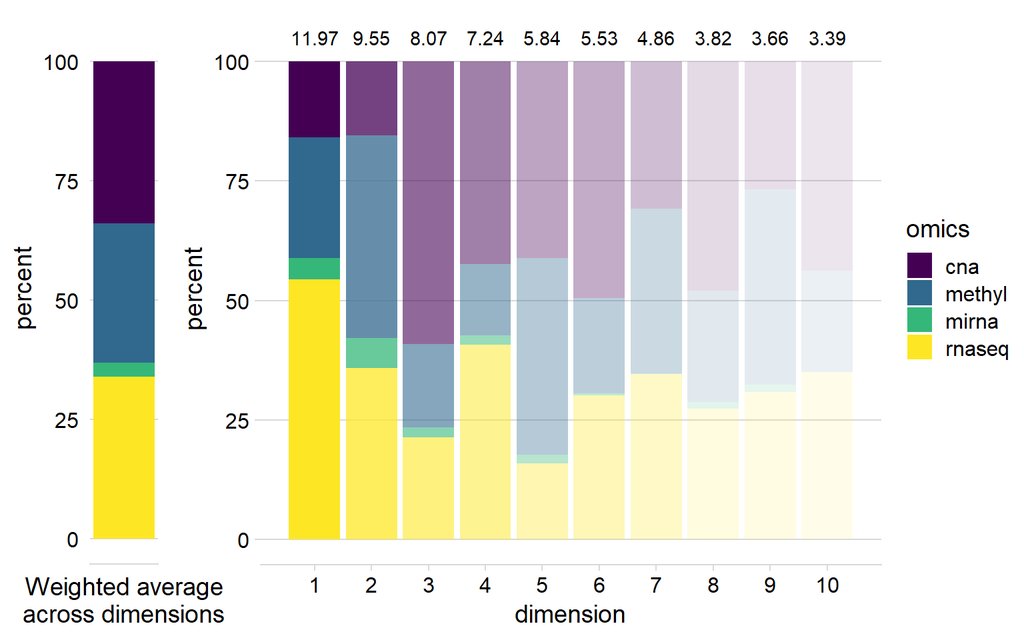

```r
plot_omics_contrib(run_padma, max_dim = 10)
```